# Olist Report

**Date: April 2025**

Project Goal: Increase the profit by identifying and addressing underperforming sellers and improving customer satisfaction through data-driven insights.

# Business Context & Objective

Olist operates a large marketplace, aggregating a wide variety of sellers and products into a unified customer platform. While Olist earns:

- A 10% commission on every product sold (excluding freight)
- And a monthly subscription fee of 80 BRL per seller

its costs are deeply affected by customer satisfaction, particularly via poor review scores, which can reduce repeat purchase rates, increase return/refund handling, or harm brand reputation.

Additionally, maintaining a large number of sellers and order volume drives IT infrastructure costs, which scale with:

- √(number of sellers)
- √(number of items sold)

Thus, our core mission was to determine:

"How can Olist maximize profit by improving review scores and managing seller performance?"

# Data Preparation

We constructed a dataset by combining features across the following dimensions:

*Seller Information:*

- seller_id, seller_city, seller_state

*Delivery Performance:*

- delay_to_carrier, wait_time

*Activity & Sales Metrics:*

- date_first_sale, date_last_sale, months_on_olist
- n_orders, quantity, quantity_per_order
- sales

*Customer Feedback:*

- share_of_five_stars, share_of_one_stars
- review_score

# Exploratory Data Analysis

We analyzed the distribution of all numerical variables, focusing on identifying:

*Key Focus Areas:*

- Outliers
- Skewed distributions
- Correlation with review_score

*Findings:*

- wait_time is positively skewed and shows a strong inverse correlation with review scores
- Some sellers have consistently poor performance (low sales, long delays, high share of 1-star reviews)
- Review score median is 5, but there's a visible tail of sellers pulling averages down

# Regression Modeling (OLS)

We used Ordinary Least Squares (OLS) regression to model how numerical features affect the review_score.

*Features Used:*

- wait_time
- delay_to_carrier
- quantity_per_order
- price
- freight_value
- seller_state (as dummies for a second model)

*Results:*

- wait_time is the most significant negative predictor (p < 0.001)
- delay_to_carrier also had a negative but weaker effect
- seller_state was not statistically significant after controlling for logistics variables
- Model R² was low (~0.19), indicating customer reviews are also influenced by unobservable factors (e.g., product quality, communication)

# Variance Inflation Factor

To ensure our regression models were not distorted by multicollinearity, we ran a VIF analysis.

All variables had acceptable VIF < 5, meaning we can trust the regression coefficients.

| Variable | VIF |
| --- | --- |
| wait_time | 1.76 |
| delay_to_carrier | 1.55 |
| quantity_per_order | 1.23 |
| price | 1.32 |
| freight_value | 1.41 |

# Profitability & IT Cost Model

**We computed total revenues, costs, and profits per seller using:**

- Revenues = 0.10 × sales + 80 × months_on_olist
- Cost of reviews = bad review rate × orders × BRL cost (1 star = 100 BRL, 2 stars = 50 BRL, 3 stars = 40 BRL)
- Profit = Revenues – Cost of reviews

**IT costs increase with marketplace size and complexity:**

- IT_cost = α *√(n_sellers) + β* √(n_items)
- α = 3,157.27 (seller cost factor)
- β = 978.23 (item cost factor)

**Key insights:**

- Many sellers are net unprofitable, costing more in bad reviews than they generate in revenue
- Nonlinear IT growth implies that keeping low-contributing sellers increases costs disproportionately
- Square root scaling shows diminishing marginal cost for additional sellers/items

# What-if Scenario: Remove Sellers

We simulated what would happen if Olist ranked and removed its least profitable sellers:

*Steps:*

- Sort sellers by descending profit (pre-IT cost)
- Compute cumulative profit and IT costs
- Calculate net profit = cumulative profit – IT cost
- Plot net profit vs number of sellers

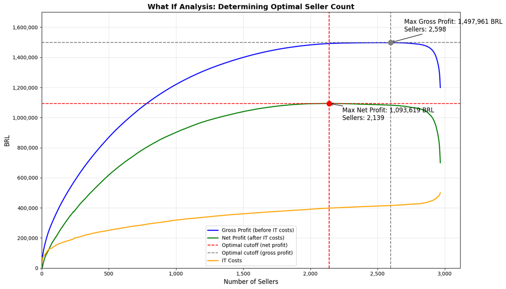

# Key Business Takeaways

*Optimal Seller Strategy:*

- Keep top 2,139 sellers (ranked by profitability)
- Remove 17.7% of sellers from gross profit maximum
- Max net profit: 1,093,619 BRL (+1.0% improvement)

*Cost Structure at Optimal Point:*

- Gross profit: 1,491,819 BRL
- IT costs: 398,200 BRL (26.7% of gross profit)
- Items sold: 66,456 (only 1.9% reduction)

*Strategic Recommendations:*

- Focus on delivery performance to improve review scores
- Implement stronger SLAs for seller shipping times
- Develop continuous seller performance monitoring
- Prioritize marketplace quality over quantity

# Recommendations

**Remove underperforming sellers**

- Sellers beyond the 2,139 cutoff reduce overall profit
- Removing them raises margins and lowers IT costs

**Strengthen delivery SLAs (service level agreements)**

- Require prompt delay_to_carrier handling
- Monitor seller shipping behavior

**Implement continuous seller scoring**

- Combine revenue, review scores, and delivery metrics
- Create automatic alerts or offboarding triggers

**Optimize IT cost scaling**

- Olist should grow seller base strategically, not blindly
- Invest in sellers with proven ROI metrics

# Conclusion

**This analysis demonstrated that:**

- Not all sellers are good for business
- Delivery performance is central to customer satisfaction
- Olist can grow profits by managing seller quality rather than quantity

**Limitations:**

- Some external factors (e.g., product category, customer behavior) not included
- Text reviews were not analyzed
- Static snapshot: no seasonal trends or seller growth stages

**By cutting unnecessary costs and rewarding high-performing sellers, Olist can become a more efficient and customer-trusted marketplace.**

# Category Profitability Analysis

**Objective:**

- Analyze which product categories contribute to Olist's profitability
- Identify categories that should be eliminated
- Maximize net profit by optimizing category mix

**Methodology:**

- Calculate revenue per category (10% sales commission + subscription fees)
- Determine cost of bad reviews per category
- Apply IT cost model to category combinations
- Find optimal subset of categories that maximize net profit

# Results: Categories to Remove

**12 categories should be removed, representing:**

- 242 sellers (8.0% of seller base)
- 19,489 items (17.7% of catalog)
- Total loss: -45,001 BRL

**Top 5 unprofitable categories:**

1. **Bed, Bath & Table:** -20,557 BRL (127 sellers)
2. **Telephony:** -14,556 BRL (58 sellers)
3. **Electronics:** -4,890 BRL (38 sellers)
4. **Audio:** -2,361 BRL (3 sellers)
5. **Home Comfort:** -1,740 BRL (3 sellers)

*Common factors: High competition, low margins, higher review costs*

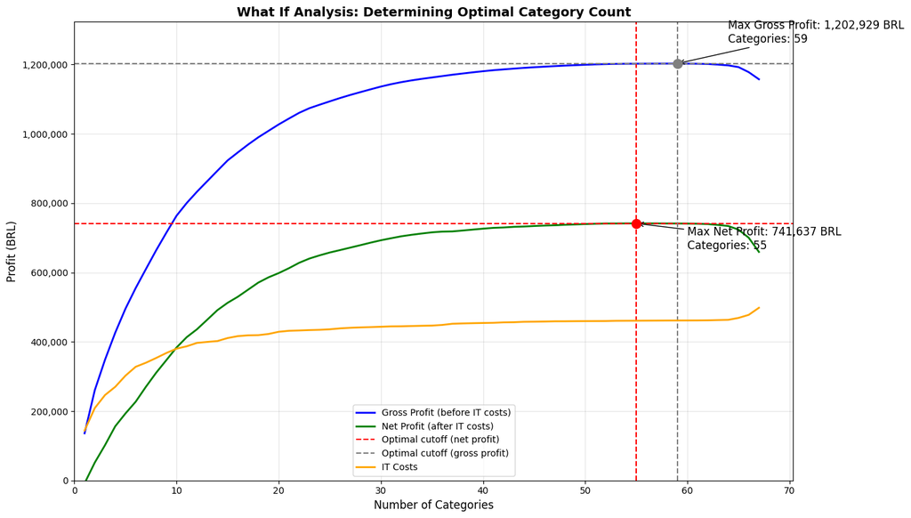

# Optimization Results

**Keeping only 55 out of 67 categories would:**

- Increase net profit by 12.5%
- Retain 92.0% of sellers
- Retain 82.3% of products
- Reduce IT costs through more focused operations

**Key insight:** Unprofitable categories often have higher wait times (12.8 days vs. marketplace average) and slightly lower review scores (3.90 vs. marketplace average)

# Recommendations for Category Management

**Short-term actions:**

- Phase out the 12 identified unprofitable categories
- Redirect affected sellers to more profitable categories
- Improve delivery performance in remaining categories

**Long-term strategy:**

- Establish regular category performance reviews
- Set profitability thresholds for introducing new categories
- Create category-specific SLAs based on profitability potential

**Implementation approach:**

- Start with removing smallest unprofitable categories (fewer sellers affected)
- Graduate to larger categories with appropriate seller transition plans

# Comparing Optimizations

**Seller optimization:**

- Removing the bottom 28% of sellers (keeping 2,139 of 2,967)
- Increases net profit to 1.09M BRL

**Category optimization:**

- Removing 18% of categories (keeping 55 of 67)
- Increases net profit to 742K BRL

**Conclusion: Targeted seller removal is more effective**

- Categories often contain mix of profitable and unprofitable sellers
- Removing entire categories risks losing profitable opportunities

**Implementation strategy:**

- First priority: Remove worst-performing individual sellers
- Second priority: Reduce investment in consistently unprofitable categories
- Long-term: Develop seller scoring system for each category's unique dynamics

# Data Validation

**Some products lack category assignments:**

- ~2.6% of sales not assigned to categories
- ~2.3% of total items not categorized
- 66 more sellers counted in category analysis due to multiple categories per seller

**Revenues:**

- Category Analysis: 2.77M BRL
- Seller Analysis: 2.81M BRL
- Difference: -1.40%

**Review costs:**

- Category Analysis: 1.61M BRL
- Seller Analysis: 1.61M BRL
- Difference: +0.17%